# Introducción a distribuciones de probabilidad

Ramon Ceballos

7/2/2021

# **Distribución Hipergeométrica**

## 1. Conceptos teóricos y matemáticos

Consideremos el experimento “extraer a la vez (o una detrás de otra, sin retornarlos) **$n$** objetos donde hay **$N$** de tipo A y **$M$** de tipo B”. Si **$X$** es variable aleatoria que mide el “número de objetos del tipo A”, diremos que **$X$** se distribuye como una Hipergeométrica con parámetros **$N,M,n$**.
$$X\sim \text{H}(N,M,n)$$

Vamos a definir algunas de las propiedades que tendrá una distribución Hipergeométrica. En referencia aeste tipo de distribución, citar que es un problema de combinatoria clásico.

- El **dominio** de $X$ será $D_X = \{0,1,2,\dots,N\}$ (en general), siempre y cuando $n>N$.
- La **función de probabilidad** vendrá dada por:
  $$f(k) = \frac{{N\choose k}{M\choose n-k}}{N+M\choose n}$$

Así, $N\choose k$ es de los $N$ objetos extraer $k$; $M\choose n-k$ es de los $M$ objetos extraer $n-k$; y $N+M\choose n$ es extraer de los $N+M$ es extraer los $n$.

- La **función de distribución** vendrá dada por:
  $$F(x) = \left\{
  \begin{array}{cl}
  0 & \text{si } x<0
  \\ \sum_{k=0}^xf(k) & \text{si } 0\le x<n
  \\ 1 & \text{si } x\ge n
  \end{array}
  \right.$$

Va a ir sumando los valores de la función de probabilidad hasta alcanzar 1.

- **Esperanza** $E(X) = \frac{nN}{N+M}$.
- **Varianza** $Var(X) = \frac{nNM}{(N+M)^2}\cdot\frac{N+M-n}{N+M-1}$.

[figure not shown]

```r
par(mfrow = c(1,2))
plot(0:30, dhyper(0:30,10,20,10),
     col = "purple", xlab = "", ylab = "",
     main = "Función de probabilidad de una H(20,10,30)")
plot(0:30, phyper(0:30,10,20,10),
     col = "purple", xlab = "", ylab = "",
     main = "Función de distribución de una H(20,10,30)",
     ylim = c(0,1))
```

```r
par(mfrow= c(1,1))
```

Ejemplos: entre un grupo de animales (perros y gatos) la probabilidad de escoger uno u otro; al pescar en un lago hay carpas y tencas y sabiendo su proporción determinar la probabilidad con distribución hipergeométrica.

## 2. Distribución Hipergeométrica en `R` y `Python`

El código de la distribución Hipergeométrica:

- En **`R`** tenemos las funciones del paquete `Rlab`: **`dhyper(x, m, n, k), phyper(q, m, N, k), qhyper(p, m, N, k), rhyper(nn, m, N, k)`** donde `m` es el número de objetos del primer tipo, `N` el número de objetos del segundo tipo y `k` el número de extracciones realizadas. El `nn` es el tamaño de la población aleatoria.
- En **`Python`** tenemos las funciones del paquete **`scipy.stats.hypergeom`**: **`pmf(k, M, n, N), cdf(k,M, n, N), ppf(q,M, n, N), rvs(M, n, N, size)`** donde `M` es el número total de objetos, `n` es el nº de objetos del primer tipo, `N` el número de objetos del segundo tipo y `k` el número de extracciones realizadas.

## 3. Ejemplos en código para la distribución Hipergeométrica (R y Python)

Supongamos que tenemos 20 animales, de los cuales 7 son perros. Queremos medir la probabilidad de encontrar un número determinado de perros si elegimos $k=12$ animales al azar.

#### **Ejemplo en R**

Empleamos las funciones anteriores.

```r
library(Rlab)
```

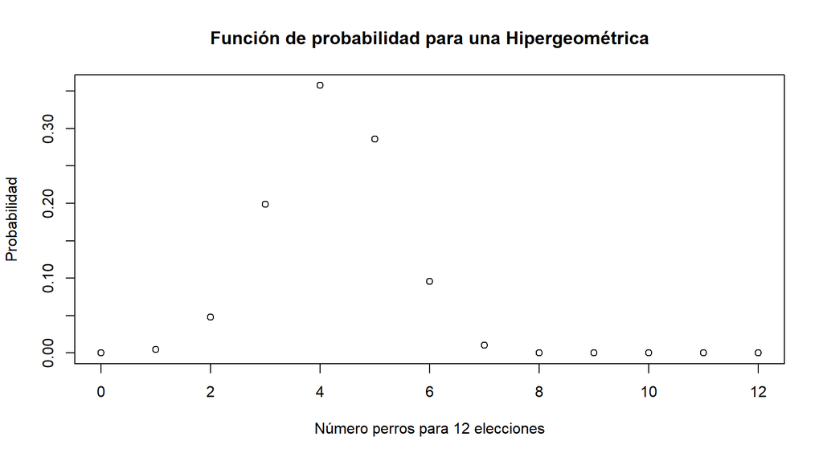

```r
#Determinamos los perros (M , valor que queremos extraer)
M = 7

#Otro animal presente en el experimento
N = 13

#Nº de extracciones a realizar
k = 12

#Función de probabilidad para una Hipergeométrica
plot(0:12,dhyper(x = 0:12, m = M, n = N, k = k,),
     title("Función de probabilidad para una Hipergeométrica"),
     xlab = "Número perros para 12 elecciones",
     ylab = "Probabilidad")
```

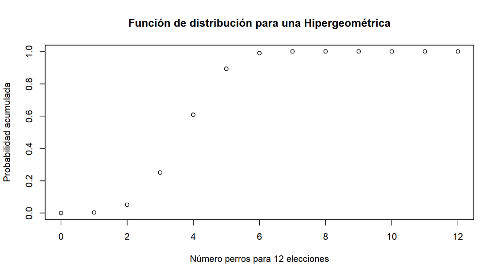

```r
#Función de distribución para una Hipergeométrica (acumulada)
plot(0:12, phyper(q = 0:12, m = M, n = N, k = k),
       title("Función de distribución para una Hipergeométrica"),
     xlab = "Número perros para 12 elecciones",
     ylab = "Probabilidad acumulada")
```

```r
#La mediana
qhyper(p = 0.5, m = M, n = N, k = k)
```

```
## [1] 4
```

[figure not shown]

```r
#Generamos datos aleatoria segun una hipergeométrica
rhyper(nn = 10000, m = M,
       n = N, k = k) -> data

#Representamos el histogrma de estos datos aleatorios
hist(data, breaks = 8,
     main = "Histograma de datos aleatorios generados \n a partir de una distribución geométrica")
```

#### **Ejemplo en Python**

Vete al script de Python del presente tema 8.